# stat433hw2

Rishav Palchowdhury

2/10/2021

```r
# flights
# ?flights
# flights[,5:10]
# colnames(flights)
# str(flights)
```

##1)

```r
colSums(is.na(flights))
```

```
##           year          month            day       dep_time sched_dep_time
##              0              0              0           8255              0
##      dep_delay       arr_time sched_arr_time      arr_delay        carrier
##           8255           8713              0           9430              0
##         flight        tailnum         origin           dest       air_time
##              0           2512              0              0           9430
##       distance           hour         minute      time_hour
##              0              0              0              0
```

This shows that 8255 flights have missing dep time. some other missing variables are arr_time, dep_delay, arr_delay, air_time, tailnum. a lot of these values must be na because the flight got cancelled. When the flight didn’t take off, there wouldn’t be any airtime values or delay either.

##2) (figure 1)

```r
flight_small <- select(flights,
                       dep_time,
                       sched_dep_time,
                       carrier,
                       flight
) %>%
mutate(
       minute_dep_time = ((dep_time %/% 100 *60) + (dep_time %% 100)),
       minute_sched_dep_time = ((sched_dep_time %/% 100 *60) + (sched_dep_time %% 100))

)
```

The table won’t knit because it is too large, I have included a screenshot of it at the end of this document

###3)

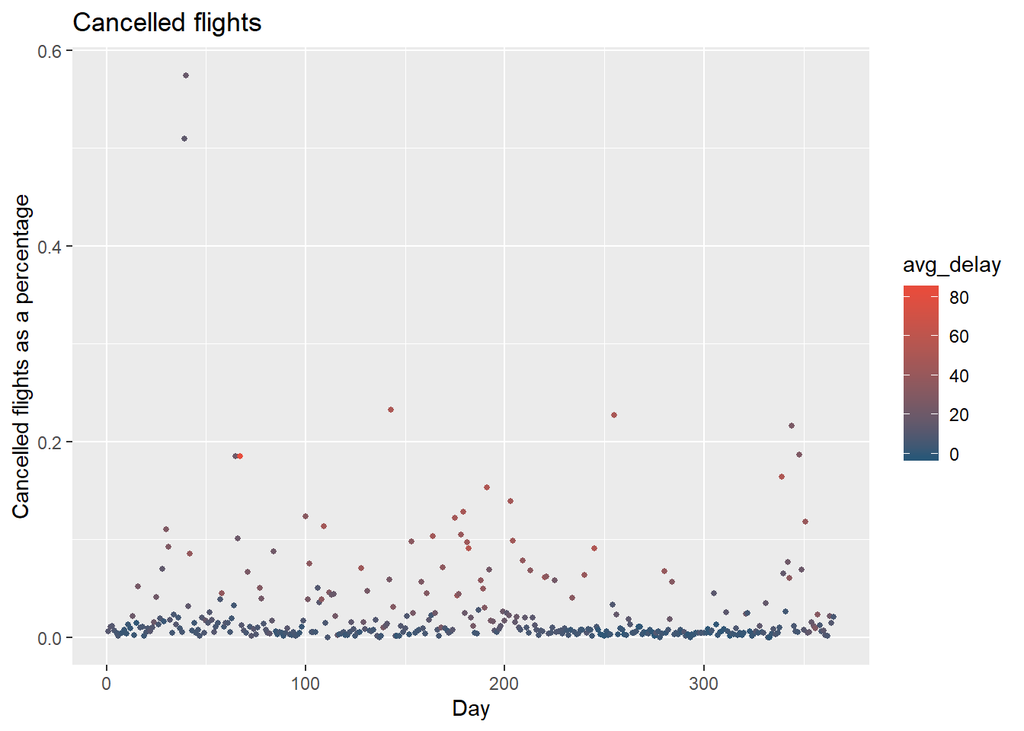

```r
flights %>%
  mutate(day_of_year = yday(time_hour)) %>%
  group_by(day_of_year) %>%
  summarise(
    num_cancelled = sum(is.na(dep_time)| is.na(arr_time)),
    total_flights = n(),
    avg_delay = mean(na.omit(dep_delay)),
    prop_cancelled = num_cancelled/total_flights
  ) %>%
  ggplot (mapping = aes (y = prop_cancelled, x = day_of_year, color = avg_delay ))+
  geom_point(size = 1)+
  scale_color_gradient(low = "#295777", high = "#E74C3C")+
  ggtitle ("Cancelled flights")+
  ylab("Cancelled flights as a percentage")+
  xlab("Day")
```

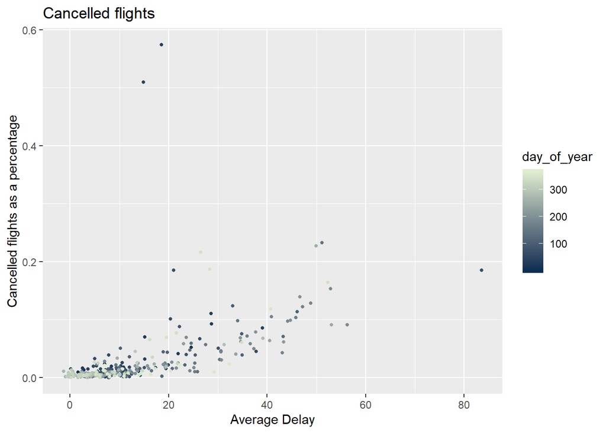

```r
flights %>%
  mutate(day_of_year = yday(time_hour)) %>%
  group_by(day_of_year) %>%
  summarise(
    num_cancelled = sum(is.na(dep_time)| is.na(arr_time)),
    total_flights = n(),
    avg_delay = mean(na.omit(dep_delay)),
    prop_cancelled = num_cancelled/total_flights
  ) %>%
  ggplot (mapping = aes (y = prop_cancelled, x = avg_delay, color = day_of_year))+
  geom_point(size = 1)+
  scale_color_gradient(high = "#DEEDCF", low = "#0A2F51")+
  ggtitle ("Cancelled flights")+
  ylab("Cancelled flights as a percentage")+
  xlab("Average Delay")
```

From first glance, it seems like the flights cancelled goes up seasonally. Flights could be cancelled because of weather, lack of tickets sold, engine failure a whole vareity of possible reasons. However, the reason for the seasonallity could be mor towards weather.

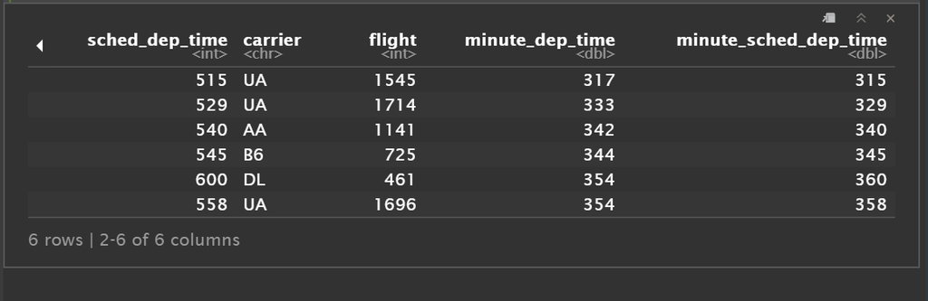

Figure 1: flight_small